# Confirmation List Break Down

## Preamble

Prepare some Notebook library installations so commands are accessible.

```r
install.packages("here")
install.packages("tidyverse")
install.packages("kableExtra")
install.packages("janitor")
```

## Reading the data into memory

The data comes from [Zone4](http://zone4.com) by downloading the list of people registered for a cross country ski day race or a multi-day event like the Alberta Cup.

```r
library(here)
library(tidyverse)
entries.raw <- read_csv(here("data", "Confirmation List.csv"))
```

Once read from the file system into an R variable we can format it as a `tibble` to explore the variables (columns) and the observations (rows) present in it.

```r
library(tidyverse)
(data <- tibble(entries.raw))
```

| ...1 | Name | firstname | lastname | city | Club | Team | Sat Feb. 19 - Interval Classic | Sun. Feb 20 - Free Technique Interval |
| --- | --- | --- | --- | --- | --- | --- | --- | --- |
| Club: Athabasca Nordic | NA | NA | NA | NA | NA | NA | NA | NA |
| NA | NA | Henrik | Asfeldt | NA | Athabasca Nordic | NA | NA | NA |
| NA | NA | Caroline | Hall | Athabasca | Athabasca Nordic | NA | U8 Girls ages 7 and under | U8 Girls up to 7 years |
| NA | NA | Sacha | Hall | Athabasca | Athabasca Nordic | NA | U12 Boys ages 10-11 | U12 Boys ages 10-11 |
| NA | NA | Benneit | Hall | Athabasca | Athabasca Nordic | NA | U14 Boys ages 12-13 | U14 Boys ages 12-13 |
| Club: Camrose Nordic Ski Club | NA | NA | NA | NA | NA | NA | NA | NA |
| NA | NA | Graeme | Thain | NA | Camrose Nordic Ski Club | NA | NA | NA |
| NA | NA | Alexandra | Thain | Camrose | Camrose Nordic Ski Club | NA | U14 Girls ages 12-13, | U14 Girls ages 12-13 |
| NA | NA | Menno | Arendz | NA | Camrose Nordic Ski Club | NA | NA | NA |
| NA | NA | Leigh | Heie | NA | Camrose Nordic Ski Club | NA | NA | NA |

[output cut: 102 more lines]

```r
names(data)
```

```
[1] "...1"
[2] "Name"
[3] "firstname"
[4] "lastname"
[5] "city"
[6] "Club"
[7] "Team"
[8] "Sat Feb. 19 - Interval Classic"
[9] "Sun. Feb 20 - Free Technique Interval"
```

Let’s clean up the original column names first.

```r
library(janitor)
(data_clean_names <- data %>% janitor::clean_names())
```

| x1 | name | firstname | lastname | city | club | team | sat_feb_19_interval_classic | sun_feb_20_free_technique_interval |
| --- | --- | --- | --- | --- | --- | --- | --- | --- |
| Club: Athabasca Nordic | NA | NA | NA | NA | NA | NA | NA | NA |
| NA | NA | Henrik | Asfeldt | NA | Athabasca Nordic | NA | NA | NA |
| NA | NA | Caroline | Hall | Athabasca | Athabasca Nordic | NA | U8 Girls ages 7 and under | U8 Girls up to 7 years |
| NA | NA | Sacha | Hall | Athabasca | Athabasca Nordic | NA | U12 Boys ages 10-11 | U12 Boys ages 10-11 |
| NA | NA | Benneit | Hall | Athabasca | Athabasca Nordic | NA | U14 Boys ages 12-13 | U14 Boys ages 12-13 |
| Club: Camrose Nordic Ski Club | NA | NA | NA | NA | NA | NA | NA | NA |
| NA | NA | Graeme | Thain | NA | Camrose Nordic Ski Club | NA | NA | NA |
| NA | NA | Alexandra | Thain | Camrose | Camrose Nordic Ski Club | NA | U14 Girls ages 12-13, | U14 Girls ages 12-13 |
| NA | NA | Menno | Arendz | NA | Camrose Nordic Ski Club | NA | NA | NA |
| NA | NA | Leigh | Heie | NA | Camrose Nordic Ski Club | NA | NA | NA |

[output cut: 102 more lines]

```r
names(data_clean_names)
```

```
[1] "x1"
[2] "name"
[3] "firstname"
[4] "lastname"
[5] "city"
[6] "club"
[7] "team"
[8] "sat_feb_19_interval_classic"
[9] "sun_feb_20_free_technique_interval"
```

## Establishing the targets

From the visual exploration of the data we see that the data of interest is located as follows:

| var | column |
| --- | --- |
| FirstName | firstname |
| LastName | lastname |
| Club | club |
| Classic | sat_feb_19_interval_classic |
| Free | sun_feb_20_free_technique_interval |
| Category | sat_feb_19_interval_classic |

The columns of the events for Saturday and Sunday not only contain the categorical values of whether the participant signed up for those events but also the category they belong to.

First we will clean up the column names, then extract the category for each participant, finally we will remove unnecessary columns.

## Data clean up and transformation

```r
clean <- data_clean_names %>%
  select("firstname","lastname","club","sat_feb_19_interval_classic", "sun_feb_20_free_technique_interval") %>%
  rename("SundayFreeTechnique"= "sun_feb_20_free_technique_interval",
         "SaturdayClassic" = "sat_feb_19_interval_classic")
clean <- clean %>% mutate(category1 = str_extract(SaturdayClassic, "^U\\d+(\\s+\\D+)+\\s\\d+-\\d+|^U\\d+(\\s+\\D+)+\\s\\d+(\\s+\\D+)+|^\\D+\\s+.*"),
                          category2 = str_extract(SundayFreeTechnique, "^U\\d+(\\s+\\D+)+\\s\\d+-\\d+|^U\\d+(\\s+\\D+)+\\s\\d+(\\s+\\D+)+|^\\D+\\s+.*"))
clean
```

| firstname | lastname | club | SaturdayClassic | SundayFreeTechnique | category1 | category2 |
| --- | --- | --- | --- | --- | --- | --- |
| NA | NA | NA | NA | NA | NA | NA |
| Henrik | Asfeldt | Athabasca Nordic | NA | NA | NA | NA |
| Caroline | Hall | Athabasca Nordic | U8 Girls ages 7 and under | U8 Girls up to 7 years | U8 Girls ages 7 and under | U8 Girls up to 7 years |
| Sacha | Hall | Athabasca Nordic | U12 Boys ages 10-11 | U12 Boys ages 10-11 | U12 Boys ages 10-11 | U12 Boys ages 10-11 |
| Benneit | Hall | Athabasca Nordic | U14 Boys ages 12-13 | U14 Boys ages 12-13 | U14 Boys ages 12-13 | U14 Boys ages 12-13 |
| NA | NA | NA | NA | NA | NA | NA |
| Graeme | Thain | Camrose Nordic Ski Club | NA | NA | NA | NA |
| Alexandra | Thain | Camrose Nordic Ski Club | U14 Girls ages 12-13, | U14 Girls ages 12-13 | U14 Girls ages 12-13 | U14 Girls ages 12-13 |
| Menno | Arendz | Camrose Nordic Ski Club | NA | NA | NA | NA |
| Leigh | Heie | Camrose Nordic Ski Club | NA | NA | NA | NA |

[output cut: 102 more lines]

Let’s remove the rows that have no information at all.

```r
(cleaned <- clean %>%
  drop_na(firstname))
```

| firstname | lastname | club | SaturdayClassic | SundayFreeTechnique | category1 | category2 |
| --- | --- | --- | --- | --- | --- | --- |
| Henrik | Asfeldt | Athabasca Nordic | NA | NA | NA | NA |
| Caroline | Hall | Athabasca Nordic | U8 Girls ages 7 and under | U8 Girls up to 7 years | U8 Girls ages 7 and under | U8 Girls up to 7 years |
| Sacha | Hall | Athabasca Nordic | U12 Boys ages 10-11 | U12 Boys ages 10-11 | U12 Boys ages 10-11 | U12 Boys ages 10-11 |
| Benneit | Hall | Athabasca Nordic | U14 Boys ages 12-13 | U14 Boys ages 12-13 | U14 Boys ages 12-13 | U14 Boys ages 12-13 |
| Graeme | Thain | Camrose Nordic Ski Club | NA | NA | NA | NA |
| Alexandra | Thain | Camrose Nordic Ski Club | U14 Girls ages 12-13, | U14 Girls ages 12-13 | U14 Girls ages 12-13 | U14 Girls ages 12-13 |
| Menno | Arendz | Camrose Nordic Ski Club | NA | NA | NA | NA |
| Leigh | Heie | Camrose Nordic Ski Club | NA | NA | NA | NA |
| Ava | Heie | Camrose Nordic Ski Club | U16 Girls ages 14-15 | U16 Girls ages 14-15 | U16 Girls ages 14-15 | U16 Girls ages 14-15 |
| Leigh | Heie | Camrose Nordic Ski Club | Masters Women ages 40-49 | NA | Masters Women ages 40-49 | NA |

[output cut: 92 more lines]

Now we can decide on a final category variable based on the two category1 and category2 variables.

```r
cleaned <- cleaned %>%
  mutate(category = if_else(is.na(category1) & is.na(category2), "coach/assistant", if_else(!is.na(category1), category1, if_else(!is.na(category2), category2, "unknown"))))
clean_dt <- cleaned %>% select(-category1, -category2)
clean_dt
```

| firstname | lastname | club | SaturdayClassic | SundayFreeTechnique | category |
| --- | --- | --- | --- | --- | --- |
| Henrik | Asfeldt | Athabasca Nordic | NA | NA | coach/assistant |
| Caroline | Hall | Athabasca Nordic | U8 Girls ages 7 and under | U8 Girls up to 7 years | U8 Girls ages 7 and under |
| Sacha | Hall | Athabasca Nordic | U12 Boys ages 10-11 | U12 Boys ages 10-11 | U12 Boys ages 10-11 |
| Benneit | Hall | Athabasca Nordic | U14 Boys ages 12-13 | U14 Boys ages 12-13 | U14 Boys ages 12-13 |
| Graeme | Thain | Camrose Nordic Ski Club | NA | NA | coach/assistant |
| Alexandra | Thain | Camrose Nordic Ski Club | U14 Girls ages 12-13, | U14 Girls ages 12-13 | U14 Girls ages 12-13 |
| Menno | Arendz | Camrose Nordic Ski Club | NA | NA | coach/assistant |
| Leigh | Heie | Camrose Nordic Ski Club | NA | NA | coach/assistant |
| Ava | Heie | Camrose Nordic Ski Club | U16 Girls ages 14-15 | U16 Girls ages 14-15 | U16 Girls ages 14-15 |
| Leigh | Heie | Camrose Nordic Ski Club | Masters Women ages 40-49 | NA | Masters Women ages 40-49 |

[output cut: 92 more lines]

The final transformation is to turn the variables for the events as categorical values, that is, if not NA then it is a 1, otherwise it is a 0.

```r
(clean_dt_final <- clean_dt %>%
  mutate(SaturdayClassic = if_else(is.na(SaturdayClassic), 0, 1),
         SundayFreeTechnique = if_else(is.na(SundayFreeTechnique), 0, 1)))
```

| firstname | lastname | club | SaturdayClassic | SundayFreeTechnique | category |
| --- | --- | --- | --- | --- | --- |
| Henrik | Asfeldt | Athabasca Nordic | 0 | 0 | coach/assistant |
| Caroline | Hall | Athabasca Nordic | 1 | 1 | U8 Girls ages 7 and under |
| Sacha | Hall | Athabasca Nordic | 1 | 1 | U12 Boys ages 10-11 |
| Benneit | Hall | Athabasca Nordic | 1 | 1 | U14 Boys ages 12-13 |
| Graeme | Thain | Camrose Nordic Ski Club | 0 | 0 | coach/assistant |
| Alexandra | Thain | Camrose Nordic Ski Club | 1 | 1 | U14 Girls ages 12-13 |
| Menno | Arendz | Camrose Nordic Ski Club | 0 | 0 | coach/assistant |
| Leigh | Heie | Camrose Nordic Ski Club | 0 | 0 | coach/assistant |
| Ava | Heie | Camrose Nordic Ski Club | 1 | 1 | U16 Girls ages 14-15 |
| Leigh | Heie | Camrose Nordic Ski Club | 1 | 0 | Masters Women ages 40-49 |

[output cut: 92 more lines]

## Answering quesions about the participants

### How many participants per category?

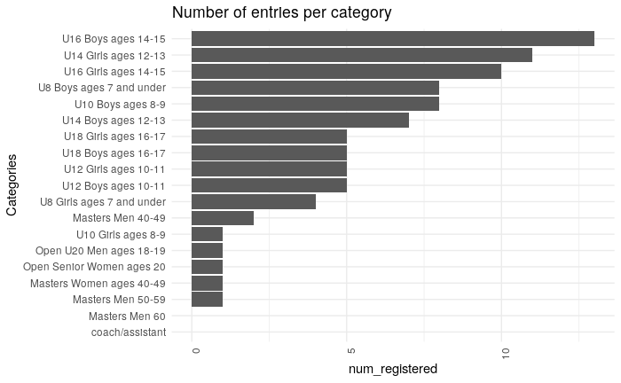

```r
library(ggplot2)
clean_dt_final %>%
  group_by(category) %>%
  summarise(num_registered=sum(SaturdayClassic)) %>%
  ggplot() +
  geom_bar(aes(reorder(category, num_registered), num_registered), stat = 'identity') +
  theme_minimal() +
  theme(axis.text.x = element_text(angle = 90, hjust = 1)) +
  labs(title = 'Number of entries per category',
    x = 'Categories') +
  coord_flip()
```

```r
NA
NA
```